# Absenteeism From Work

```r
set.seed(123)
```

```r
# Develop Model on training data
fit_XGB = gbm(Absenteeism.time.in.hours~., data = train, n.trees = 500, interaction.depth = 2)
```

```
Distribution not specified, assuming gaussian ...
```

```r
# Predict training data
pred_XGB_train = predict(fit_XGB, train[,names(test) != "Absenteeism.time.in.hours"], n.trees = 500)
```

```r
# Predict testing data
pred_XGB_test = predict(fit_XGB,test[,names(test) != "Absenteeism.time.in.hours"], n.trees = 500)
```

```r
# For training data
print(postResample(pred = pred_XGB_train, obs = train[,107]))
```

```
     RMSE  Rsquared       MAE
1.9885240 0.6340229 1.4744135
```

```r
# For testing data
print(postResample(pred = pred_XGB_test, obs = test[,107]))
```

```
     RMSE  Rsquared       MAE
2.6381222 0.4349374 1.6884038
```

### Dimensionality Reduction using PCA

Principal component analysis is a method of extracting important variables (in the form of components) from a large set of variables available in a dataset. It extracts low dimensional sets of features from a high dimensional dataset with a motive to capture as much information as possible. With fewer variables, visualization also becomes much more meaningful.

```r
# Principal Component Analysis
prin_comp = prcomp(train)
```

```r
# Compute standard deviation of each principal component
std_dev = prin_comp$sdev
```

```r
# Compute variance
pr_var = std_dev^2
```

```r
# Proportion of variance explained
prop_varex = pr_var/sum(pr_var)
```

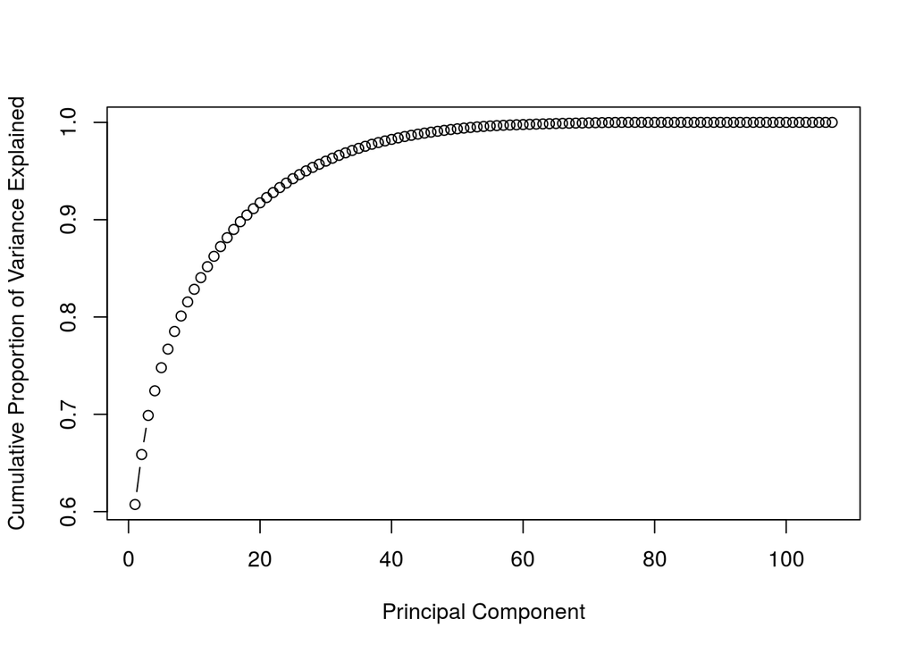

```r
# Cumulative screen plot
plot(cumsum(prop_varex), xlab = "Principal Component",
     ylab = "Cumulative Proportion of Variance Explained",
     type = "b")
```

```r
# Add training set with principal components
train.data = data.frame(Absenteeism.time.in.hours = train$Absenteeism.time.in.hours, prin_comp$x)
```

```r
# From the above plot selecting 45 components since it explains almost 95+ % data variance
train.data =train.data[,1:45]
```

```r
# Transforming test into PCA
test.data = predict(prin_comp, newdata = test)
test.data = as.data.frame(test.data)
```

```r
# Selecting the first 45 components
test.data=test.data[,1:45]
```

### Model Development after Dimensionality Reduction

After a thorough preprocessing we’ll be using some regression models on our processed data to predict the target variable. Following are the models which we have built –

A decision tree is a decision support tool that uses a tree-like graph or model of decisions and their possible consequences, including chance event outcomes, resource costs, and utility. Each branch connects nodes with “and” and multiple branches are connected by “or”. It can be used for classification and regression.It is a supervised machine learning algorithm.

Accept continuous and categorical variables as independent variables. Extremely easy to understand by the business users.

```r
# Develop Model on training data
fit_DT = rpart(Absenteeism.time.in.hours ~., data = train.data, method = "anova")
```

```r
# Predict training data
pred_DT_train = predict(fit_DT, train.data)
```

```r
# Predict testing data
pred_DT_test = predict(fit_DT,test.data)
```

```r
# For training data
print(postResample(pred = pred_DT_train, obs = train$Absenteeism.time.in.hours))
```

```
     RMSE  Rsquared       MAE
0.4024881 0.9847349 0.2348649
```

```r
# For testing data
print(postResample(pred = pred_DT_test, obs = test$Absenteeism.time.in.hours))
```

```
     RMSE  Rsquared       MAE
0.3551083 0.9896864 0.2089476
```

#### Linear Regression

```r
# Develop Model on training data
fit_LR = lm(Absenteeism.time.in.hours ~ ., data = train.data)
```

```r
# Predict training data
pred_LR_train = predict(fit_LR, train.data)
```

```r
# Predict testing data
pred_LR_test = predict(fit_LR,test.data)
```

```r
# For training data
print(postResample(pred = pred_LR_train, obs = train$Absenteeism.time.in.hours))
```

```
       RMSE    Rsquared         MAE
0.001767428 0.999999706 0.001016899
```

```r
# For testing data
print(postResample(pred = pred_LR_test, obs =test$Absenteeism.time.in.hours))
```

```
        RMSE     Rsquared          MAE
0.0014702081 0.9999998400 0.0009702523
```

#### Random Forest

Random Forest is an ensemble technique that consists of many decision trees. The idea behind random forest is to build n number of trees to have more accuracy in the dataset. It is called random forest as we are building n no. of trees randomly.

In other words, to build the decision tree it selects randomly n no of variables and n no of observations to build each decision tree. It means to build each decision tree on random forest we are not going to use the same data.

```r
# Develop Model on training data
fit_RF = randomForest(Absenteeism.time.in.hours~., data = train.data)
```

```r
# Predict training data
pred_RF_train = predict(fit_RF, train.data)
```

```r
# Predict testing data
pred_RF_test = predict(fit_RF,test.data)
```

```r
# For training data
print(postResample(pred = pred_RF_train, obs = train$Absenteeism.time.in.hours))
```

```
     RMSE  Rsquared       MAE
0.3112539 0.9938584 0.1504713
```

```r
# For testing data
print(postResample(pred = pred_RF_test, obs = test$Absenteeism.time.in.hours))
```

```
     RMSE  Rsquared       MAE
0.7574964 0.9692086 0.3259651
```

Gradient boosting is a machine learning technique for regression and classification problems, which produces a prediction model in the form of an ensemble of weak prediction models, typically decision trees.

It builds the model in a stage-wise fashion like other boosting methods do, and it generalizes them by allowing optimization of an arbitrary differentiable loss function.

```r
# Develop Model on training data
fit_XGB = gbm(Absenteeism.time.in.hours~., data = train.data, n.trees = 500, interaction.depth = 2)
```

```
Distribution not specified, assuming gaussian ...
```

```r
# Predict training data
pred_XGB_train = predict(fit_XGB, train.data, n.trees = 500)
```

```r
# Predict testing data
pred_XGB_test = predict(fit_XGB,test.data, n.trees = 500)
```

```r
# For training data
print(postResample(pred = pred_XGB_train, obs = train$Absenteeism.time.in.hours))
```

```
      RMSE   Rsquared        MAE
0.11676608 0.99873245 0.08295036
```

```r
# For testing data
print(postResample(pred = pred_XGB_test, obs = test$Absenteeism.time.in.hours))
```

```
     RMSE  Rsquared       MAE
0.7212136 0.9575050 0.2974754
```

Root Mean Square Error (RMSE) is the standard deviation of the residuals (prediction errors). Residuals are a measure of how far from the regression line data points are, RMSE is a measure of how spread out these residuals are. In other words, it tells you how concentrated the data is around the line of best fit. Whereas R-squared is a relative measure of fit, RMSE is an absolute measure of fit. As the square root of a variance, RMSE can be interpreted as the standard deviation of the unexplained variance, and has the useful property of being in the same units as the response variable. Lower values of RMSE and higher value of R-Squared Value indicate better fit.

From the observation of all RMSE Value and R-Squared Value we have concluded that Linear Regression Model has minimum value of RMSE and it’s R-Squared Value is also maximum (i.e. 1). The RMSE value of Testing data and Training does not differs a lot, implies that it is not the case of overfitting.